# 关联规则 与 Apriori 算法实现商品推荐

## 基础包导入与数据预览

```python
import pandas as pd
import numpy as np

# 基础绘图库
import matplotlib.pyplot as plt
import seaborn as sns
# %matplotlib inline
# 各种细节配置如 文字大小，图例文字等杂项
large = 22; med = 16; small = 12
params = {'axes.titlesize': large,
          'legend.fontsize': med,
          'figure.figsize': (16, 10),
          'axes.labelsize': med,
          'axes.titlesize': med,
          'xtick.labelsize': med,
          'ytick.labelsize': med,
          'figure.titlesize': large}
plt.rcParams.update(params)
plt.style.use('seaborn-whitegrid')
sns.set_style("white")
plt.rc('font', **{'family': 'Microsoft YaHei, SimHei'})  # 设置中文字体的支持
# sns.set(font='SimHei')  # 解决Seaborn中文显示问题，但会自动添加背景灰色网格

plt.rcParams['axes.unicode_minus'] = False
# 解决保存图像是负号'-'显示为方块的问题
```

```python
df = pd.read_csv('bike_data.csv', encoding='gbk')
df.info(); df.head()
```

```
<class 'pandas.core.frame.DataFrame'>
RangeIndex: 52761 entries, 0 to 52760
Data columns (total 3 columns):
OrderNumber    52761 non-null object
LineNumber     52761 non-null int64
Model          52761 non-null object
dtypes: int64(1), object(2)
memory usage: 1.2+ MB
```

|  | OrderNumber | LineNumber | Model |
| --- | --- | --- | --- |
| 0 | cumid51178 | 1 | 山地英骑 |
| 1 | cumid51178 | 2 | 山地车水壶架 |
| 2 | cumid51178 | 3 | 运动水壶 |
| 3 | cumid51184 | 1 | 山地英骑 |
| 4 | cumid51184 | 2 | hl山地外胎 |

数据参数

- OrderNumber：客户昵称
- LineNumber：购买顺序，如前三行分别表示同一个客户购买的三样商品的顺序
- Model：商品名

## 探索性数据分析

```python
# 检查重复值
df.duplicated().sum()
```

```
0
```

###### 商品种类及销量排名

```python
# 商品种类探索
print(f"数据集中共有{df['Model'].nunique()}种商品")

model_names = df['Model'].unique()
print("商品名分别为：")
# 5 个为一行显示
for i in range(0, len(model_names), 5):
      print(model_names[i:i+5])
```

```
数据集中共有37种商品
商品名分别为：
['山地英骑' '山地车水壶架' '运动水壶' 'hl山地外胎' '山地车内胎']
['运动型头盔' '普通公路车' '公路车内胎' 'hl公路外胎' '竞速公路车']
['公路车水壶架' '长袖骑车衣' '山地车挡泥板' '自行车帽' '山地车400']
['ml山地外胎' '修补工具' '山地车500' '公路车550' '短袖经典车衣']
['旅游型自行车(大)' '竞速袜' '半掌手套' '公路车350' 'ml公路外胎']
['水壶包' '旅游型自行车(小)' '旅游型自行车(中)' '旅游车内胎' 'll公路车外胎']
['旅游自行车外胎(通用)' '万能自行车座' '洗车喷剂' '经典背心' 'll山地胎']
['故障栓钩' "Women's Mountain Shorts"]
```

```python
# 最畅销的 15 种商品
 ## 往 reset_index 中添加 name 参数可快速重命名列名
grouped = df.groupby('Model')['Model'].count().reset_index(name='count')
grouped.head()
```

|  | Model | count |
| --- | --- | --- |
| 0 | Women's Mountain Shorts | 958 |
| 1 | hl公路外胎 | 804 |
| 2 | hl山地外胎 | 1331 |
| 3 | ll公路车外胎 | 980 |
| 4 | ll山地胎 | 799 |

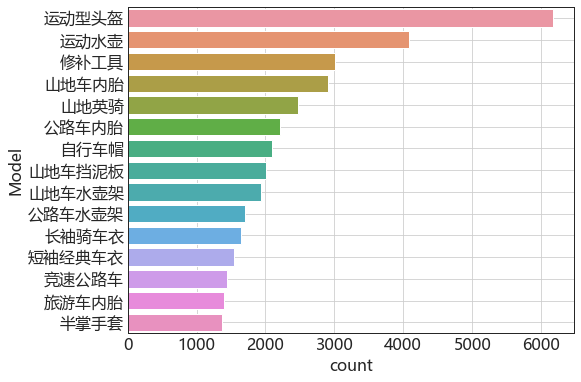

```python
top_15 = grouped.sort_values(by='count', ascending=False).head(15)

plt.figure(figsize=(8, 6))
sns.barplot(data=top_15, x='count', y='Model')
plt.grid(True)
```

```python
top_15 = top_15['Model'].tolist()
print('初步分析，该自行车店的排名前15的畅销单品为如下：')
for i in range(0, len(top_15), 5):
    print(top_15[i:i+5])
```

```
初步分析，该自行车店的排名前15的畅销单品为如下：
['运动型头盔', '运动水壶', '修补工具', '山地车内胎', '山地英骑']
['公路车内胎', '自行车帽', '山地车挡泥板', '山地车水壶架', '公路车水壶架']
['长袖骑车衣', '短袖经典车衣', '竞速公路车', '旅游车内胎', '半掌手套']
```

## 使用 Apriori 算法求解关联规则

```python
import Apriori as apri
```

###### 1. 生成购物篮

- 将同一个客户购买的所有商品放入同一个购物篮

```python
# 使用 Apriori 包中的 dataconvert 函数
# 需要传入的参数，可以当作固定的来用
"""
arulesdata：数据集 -- DataFrame
tidvar: “分类的索引”，即划分购物篮的标准，本案例是根据客户 OrderNumber -- object类型
itemvar：将什么东西放进篮子里，本案例是将数据集中的商品，也就是 Model 列放入篮子 -- object类型
data_type: 默认选择 'inverted'，库中提供的不变
"""
## 注意：需要注意传入的参数类型，只要对了，直接套用就不是什么难事
```

```
"\narulesdata：数据集 -- DataFrame\ntidvar: “分类的索引”，即划分购物篮的标准，本案例是根据客户 OrderNumber -- object类型\nitemvar：将什么东西放进篮子里，本案例是将数据集中的商品，也就是 Model 列放入篮子 -- object类型\ndata_type: 默认选择 'inverted'，库中提供的不变\n"
```

```python
# 需要稍微等待一下
baskets = apri.dataconvert(arulesdata=df, tidvar='OrderNumber',
                           itemvar='Model', data_type='inverted')
```

```
inverted index type dataSet
```

```python
# 返回的购物篮是一个大列表，大列表中的每一个小列表表示一个篮子
# 购物篮个数刚好等于数据集中的客户数量
type(baskets), len(baskets) == df['OrderNumber'].nunique()
```

```
(list, True)
```

```python
# 预览前五个购物篮中的物品
baskets[:5]
```

```
[['普通公路车', '公路车水壶架'],
 ['运动型头盔', '旅游型自行车(中)'],
 ['山地英骑', '山地车水壶架', '运动水壶'],
 ['万能自行车座', '公路车内胎', 'hl公路外胎', '普通公路车'],
 ['普通公路车', '公路车水壶架', '运动水壶', '运动型头盔', '长袖骑车衣']]
```

```python
len(baskets)
```

```
21255
```

###### 2. 生成关联规则

根据排列组合，可知这些交易将会产生 C 21255 2 即 21255×21254÷2 这么多个关联规则

```
首先就要满足支持度的要求，太小则直接被删去，支持度的大小可根据关联规则的多少调整
如果关联规则很少，可根据实际情况放宽支持度的要求
```

参数说明:

```
+ minSupport:最小支持度阈值
+ minConf:最小置信度阈值
+ minlen:规则最小长度
+ maxlen:规则最大长度，一般2就够了
```

这里，minSupport 或 minConf 设定越低，产生的规则越多，计算量也就越大

同样，规则的最小/最大长度这里可能也会令你迷惑，公路车=>公路车外胎，

这条规则只涉及到用户的购买的物品；公路车=>公路车外胎=>修理工具”，

这条规则就涉及到两个字段的信息，是两个维上的一条关联规则(长度为2)。

```python
# 最小支持度 minSupport 为什么设置得这么小？因为两个规则的其实很少
 ## minSupport 支持度如果在这个值以下的就不选入了
 ## minConf：min_confidence：置信度如果在这个值以下就不选入了
result = apri.arules(dataset=baskets, minSupport=0.01, minConf=0.1,
                  minlen=1, maxlen=2)
```

```
frozenset({'ll山地胎'}) --> frozenset({'山地车内胎'}) conf: 0.560700876095119
frozenset({'山地车内胎'}) --> frozenset({'ll山地胎'}) conf: 0.15405777166437415
frozenset({'旅游自行车外胎(通用)'}) --> frozenset({'修补工具'}) conf: 0.24404086265607264
frozenset({'修补工具'}) --> frozenset({'旅游车内胎'}) conf: 0.12026578073089701
frozenset({'旅游车内胎'}) --> frozenset({'修补工具'}) conf: 0.25912670007158195
frozenset({'ml公路外胎'}) --> frozenset({'修补工具'}) conf: 0.2898876404494382
frozenset({'洗车喷剂'}) --> frozenset({'修补工具'}) conf: 0.3067129629629629
frozenset({'ml山地外胎'}) --> frozenset({'修补工具'}) conf: 0.29547553093259465
frozenset({'修补工具'}) --> frozenset({'ml山地外胎'}) conf: 0.106312292358804
frozenset({'公路车350'}) --> frozenset({'运动型头盔'}) conf: 0.3358449946178687
frozenset({'hl公路外胎'}) --> frozenset({'修补工具'}) conf: 0.2699004975124378
frozenset({'半掌手套'}) --> frozenset({'运动水壶'}) conf: 0.23037417461482027
frozenset({'长袖骑车衣'}) --> frozenset({'山地车挡泥板'}) conf: 0.14494518879415347
frozenset({'山地车挡泥板'}) --> frozenset({'长袖骑车衣'}) conf: 0.11817279046673286
frozenset({'自行车帽'}) --> frozenset({'长袖骑车衣'}) conf: 0.12219570405727923
frozenset({'长袖骑车衣'}) --> frozenset({'自行车帽'}) conf: 0.1559074299634592
frozenset({'山地车挡泥板'}) --> frozenset({'山地车内胎'}) conf: 0.14597815292949357
frozenset({'山地车内胎'}) --> frozenset({'山地车挡泥板'}) conf: 0.10110041265474555
frozenset({'ml山地外胎'}) --> frozenset({'运动型头盔'}) conf: 0.31209602954755306
frozenset({'ll山地胎'}) --> frozenset({'修补工具'}) conf: 0.3579474342928661
frozenset({'短袖经典车衣'}) --> frozenset({'运动水壶'}) conf: 0.2530904359141184
frozenset({'旅游型自行车(小)'}) --> frozenset({'公路车水壶架'}) conf: 0.27171314741035857
frozenset({'公路车水壶架'}) --> frozenset({'旅游型自行车(小)'}) conf: 0.20035252643948295
frozenset({'旅游型自行车(小)'}) --> frozenset({'运动水壶'}) conf: 0.24621513944223108
frozenset({'自行车帽'}) --> frozenset({'运动型头盔'}) conf: 0.2224343675417661
frozenset({'修补工具'}) --> frozenset({'公路车内胎'}) conf: 0.18471760797342193
frozenset({'公路车内胎'}) --> frozenset({'修补工具'}) conf: 0.2509025270758123
frozenset({'ll公路车外胎'}) --> frozenset({'公路车内胎'}) conf: 0.5265306122448979
frozenset({'公路车内胎'}) --> frozenset({'ll公路车外胎'}) conf: 0.23285198555956682
frozenset({'ll公路车外胎'}) --> frozenset({'修补工具'}) conf: 0.3520408163265306
frozenset({'修补工具'}) --> frozenset({'ll公路车外胎'}) conf: 0.11461794019933556
frozenset({'水壶包'}) --> frozenset({'运动水壶'}) conf: 0.40084985835694054
frozenset({'自行车帽'}) --> frozenset({'短袖经典车衣'}) conf: 0.1575178997613365
frozenset({'短袖经典车衣'}) --> frozenset({'自行车帽'}) conf: 0.21470396877033182
frozenset({'旅游自行车外胎(通用)'}) --> frozenset({'运动型头盔'}) conf: 0.26787741203178206
frozenset({'旅游车内胎'}) --> frozenset({'运动型头盔'}) conf: 0.3235504652827488
frozenset({'山地英骑'}) --> frozenset({'修补工具'}) conf: 0.13201453371013325
frozenset({'修补工具'}) --> frozenset({'山地英骑'}) conf: 0.10863787375415283
frozenset({'修补工具'}) --> frozenset({'hl山地外胎'}) conf: 0.12325581395348838
frozenset({'hl山地外胎'}) --> frozenset({'修补工具'}) conf: 0.2787377911344854
```

[output cut: 76 more lines]

```
frozenset({'公路车水壶架'}) --> frozenset({'竞速公路车', '运动水壶'}) conf: 0.28495887191539365
frozenset({'运动水壶'}) --> frozenset({'竞速公路车', '公路车水壶架'}) conf: 0.11898920510304219
frozenset({'竞速公路车'}) --> frozenset({'公路车水壶架', '运动水壶'}) conf: 0.33610533610533605
frozenset({'山地车水壶架'}) --> frozenset({'运动型头盔', '运动水壶'}) conf: 0.22977846470891292
frozenset({'运动水壶'}) --> frozenset({'运动型头盔', '山地车水壶架'}) conf: 0.10942100098135427
frozenset({'山地车水壶架'}) --> frozenset({'运动型头盔', '山地英骑'}) conf: 0.11334363730036062
frozenset({'山地英骑'}) --> frozenset({'山地车内胎', 'hl山地外胎'}) conf: 0.13362939039160274
frozenset({'hl山地外胎'}) --> frozenset({'山地车内胎', '山地英骑'}) conf: 0.24868519909842227
frozenset({'山地车内胎'}) --> frozenset({'hl山地外胎', '山地英骑'}) conf: 0.11382393397524072
frozenset({'hl山地外胎'}) --> frozenset({'山地车内胎', '运动型头盔'}) conf: 0.2877535687453043
frozenset({'山地车内胎'}) --> frozenset({'hl山地外胎', '运动型头盔'}) conf: 0.13170563961485557
frozenset({'公路车水壶架'}) --> frozenset({'运动型头盔', '运动水壶'}) conf: 0.2209165687426557
frozenset({'山地车水壶架'}) --> frozenset({'山地英骑', '运动水壶'}) conf: 0.30345182895414735
frozenset({'运动水壶'}) --> frozenset({'山地英骑', '山地车水壶架'}) conf: 0.14450441609421
frozenset({'山地英骑'}) --> frozenset({'运动水壶', '山地车水壶架'}) conf: 0.23778764634638677
```

[output not shown]

```python
type(result)
```

```
pandas.core.frame.DataFrame
```

```python
result.head(5) # 会自动根据 支持度 和 置信度 的值计算出 提升度 lift
```

|  | lhs |  | rhs | support | confidence | lift |
| --- | --- | --- | --- | --- | --- | --- |
| 0 | (ll山地胎) | ==> | (山地车内胎) | 0.021077 | 0.560701 | 4.098245 |
| 1 | (山地车内胎) | ==> | (ll山地胎) | 0.021077 | 0.154058 | 4.098245 |
| 2 | (旅游自行车外胎(通用)) | ==> | (修补工具) | 0.010115 | 0.244041 | 1.723285 |
| 3 | (修补工具) | ==> | (旅游车内胎) | 0.017031 | 0.120266 | 1.829813 |
| 4 | (旅游车内胎) | ==> | (修补工具) | 0.017031 | 0.259127 | 1.829813 |

结果说明: 以 result 第一行为例

[output not shown]

```python
# 结果也不多，100 来个
result.info()
```

```
<class 'pandas.core.frame.DataFrame'>
RangeIndex: 102 entries, 0 to 101
Data columns (total 6 columns):
lhs           102 non-null object
              102 non-null object
rhs           102 non-null object
support       102 non-null float64
confidence    102 non-null float64
lift          102 non-null float64
dtypes: float64(3), object(3)
memory usage: 4.9+ KB
```

###### 3. 筛选互补品和互斥品

```python
# 互补品
# lift 提升度首先要大于1，然后再排序选择自己希望深究的前 n 个
hubu = result[result['lift'] > 1].sort_values(by='lift', ascending=False).head(20)

# 互斥品
huchi = result[result['lift'] < 1].sort_values(by='lift', ascending=True).head(20)
```

```python
hubu # 结果也合情合理
```

|  | lhs |  | rhs | support | confidence | lift |
| --- | --- | --- | --- | --- | --- | --- |
| 71 | (旅游车内胎) | ==> | (旅游自行车外胎(通用)) | 0.035662 | 0.542591 | 13.090553 |
| 70 | (旅游自行车外胎(通用)) | ==> | (旅游车内胎) | 0.035662 | 0.860386 | 13.090553 |
| 92 | (公路车内胎) | ==> | (hl公路外胎) | 0.025970 | 0.249097 | 6.585282 |
| 93 | (hl公路外胎) | ==> | (公路车内胎) | 0.025970 | 0.686567 | 6.585282 |
| 65 | (公路车内胎) | ==> | (ml公路外胎) | 0.027288 | 0.261733 | 6.250710 |
| 66 | (ml公路外胎) | ==> | (公路车内胎) | 0.027288 | 0.651685 | 6.250710 |
| 28 | (公路车内胎) | ==> | (ll公路车外胎) | 0.024277 | 0.232852 | 5.050274 |
| 27 | (ll公路车外胎) | ==> | (公路车内胎) | 0.024277 | 0.526531 | 5.050274 |
| 69 | (竞速公路车) | ==> | (ll公路车外胎) | 0.015761 | 0.232155 | 5.035163 |
| 68 | (ll公路车外胎) | ==> | (竞速公路车) | 0.015761 | 0.341837 | 5.035163 |
| 82 | (山地车内胎) | ==> | (hl山地外胎) | 0.043049 | 0.314649 | 5.024695 |
| 81 | (hl山地外胎) | ==> | (山地车内胎) | 0.043049 | 0.687453 | 5.024695 |
| 60 | (山地车内胎) | ==> | (ml山地外胎) | 0.034204 | 0.250000 | 4.906510 |
| 59 | (ml山地外胎) | ==> | (山地车内胎) | 0.034204 | 0.671283 | 4.906510 |
| 55 | (竞速公路车) | ==> | (公路车水壶架) | 0.026300 | 0.387387 | 4.837790 |
| 54 | (公路车水壶架) | ==> | (竞速公路车) | 0.026300 | 0.328437 | 4.837790 |
| 87 | (公路车水壶架) | ==> | (运动水壶) | 0.071183 | 0.888954 | 4.635604 |
| 86 | (运动水壶) | ==> | (公路车水壶架) | 0.071183 | 0.371197 | 4.635604 |
| 98 | (山地车水壶架) | ==> | (运动水壶) | 0.076359 | 0.836167 | 4.360336 |
| 99 | (运动水壶) | ==> | (山地车水壶架) | 0.076359 | 0.398184 | 4.360336 |

```python
huchi
```

|  | lhs |  | rhs | support | confidence | lift |
| --- | --- | --- | --- | --- | --- | --- |
| 91 | (长袖骑车衣) | ==> | (运动水壶) | 0.010303 | 0.133374 | 0.695501 |
| 85 | (公路车水壶架) | ==> | (运动型头盔) | 0.017690 | 0.220917 | 0.760911 |
| 24 | (自行车帽) | ==> | (运动型头盔) | 0.021924 | 0.222434 | 0.766139 |
| 44 | (山地车挡泥板) | ==> | (运动水壶) | 0.014444 | 0.152433 | 0.794888 |
| 45 | (ml公路外胎) | ==> | (运动型头盔) | 0.010398 | 0.248315 | 0.855279 |
| 88 | (运动水壶) | ==> | (运动型头盔) | 0.049682 | 0.259078 | 0.892350 |
| 89 | (运动型头盔) | ==> | (运动水壶) | 0.049682 | 0.171123 | 0.892350 |
| 34 | (旅游自行车外胎(通用)) | ==> | (运动型头盔) | 0.011103 | 0.267877 | 0.922660 |
| 61 | (山地车挡泥板) | ==> | (运动型头盔) | 0.025594 | 0.270109 | 0.930347 |
| 37 | (修补工具) | ==> | (山地英骑) | 0.015385 | 0.108638 | 0.932216 |
| 36 | (山地英骑) | ==> | (修补工具) | 0.015385 | 0.132015 | 0.932216 |
| 64 | (山地车水壶架) | ==> | (运动型头盔) | 0.025029 | 0.274086 | 0.944043 |
| 90 | (长袖骑车衣) | ==> | (运动型头盔) | 0.021642 | 0.280146 | 0.964918 |
| 56 | (竞速公路车) | ==> | (运动型头盔) | 0.019054 | 0.280665 | 0.966706 |
| 79 | (山地英骑) | ==> | (山地车内胎) | 0.015573 | 0.133629 | 0.976717 |
| 80 | (山地车内胎) | ==> | (山地英骑) | 0.015573 | 0.113824 | 0.976717 |
| 72 | (山地英骑) | ==> | (运动型头盔) | 0.033404 | 0.286637 | 0.987274 |
| 73 | (运动型头盔) | ==> | (山地英骑) | 0.033404 | 0.115054 | 0.987274 |

### 关联规则结果分析

不要期望每个规则都有意义，要结合业务思考

[output not shown]

## 根据关联规则结果推荐产品

需要结合业务需求

- 获得最大营销响应度？-- 看置信度，越高越好
- 销售最大化？-- 看提升度，越高越好
- 用户未产生消费，我们向其推荐商品？

```python
# 注意数据类型，frozenset，需要拆一下
result['lhs'][1], type(result['lhs'][1])
```

```
(frozenset({'山地车内胎'}), frozenset)
```

#### 以获得最高的营销相应率为目标

如果一个新客户刚刚下单了 山地车英骑 这个产品，

如果希望获得最高的营销响应率，那在他付费成功页面上最应该推荐什么产品？

- 目标：获得最高的营销响应率

```python
# 使用的是左手规则：lhs(left hand rule)，lhs 表示的是购买的产品
 ## 使用 frozenset 来对字典的键进行选择
purchase_good = result[result['lhs'] == frozenset({'山地英骑'})]
purchase_good.sample(3)
```

|  | lhs |  | rhs | support | confidence | lift |
| --- | --- | --- | --- | --- | --- | --- |
| 36 | (山地英骑) | ==> | (修补工具) | 0.015385 | 0.132015 | 0.932216 |
| 75 | (山地英骑) | ==> | (hl山地外胎) | 0.023524 | 0.201857 | 3.223495 |
| 95 | (山地英骑) | ==> | (山地车水壶架) | 0.034110 | 0.292693 | 3.205144 |

```python
# 根据置信度排序
purchase_good.sort_values(by='confidence', ascending=False)
# 根据下表，应该首先推荐山地车挡泥板
```

|  | lhs |  | rhs | support | confidence | lift |
| --- | --- | --- | --- | --- | --- | --- |
| 62 | (山地英骑) | ==> | (山地车挡泥板) | 0.034345 | 0.294711 | 3.110273 |
| 95 | (山地英骑) | ==> | (山地车水壶架) | 0.034110 | 0.292693 | 3.205144 |
| 72 | (山地英骑) | ==> | (运动型头盔) | 0.033404 | 0.286637 | 0.987274 |
| 97 | (山地英骑) | ==> | (运动水壶) | 0.027711 | 0.237788 | 1.239984 |
| 75 | (山地英骑) | ==> | (hl山地外胎) | 0.023524 | 0.201857 | 3.223495 |
| 79 | (山地英骑) | ==> | (山地车内胎) | 0.015573 | 0.133629 | 0.976717 |
| 36 | (山地英骑) | ==> | (修补工具) | 0.015385 | 0.132015 | 0.932216 |

#### 以最大化总体销售额为目标

如果一个新客户刚下单了 山地英骑 这个产品，

如果希望最大化提升总体的销售额，那么在他付费成功的页面上应该推荐什么产品？

- 目标：最大化销售额

```python
purchase_good.sort_values(by='lift', ascending=False)
# 由下表可知，应该首推 hl 山地车外胎
```

|  | lhs |  | rhs | support | confidence | lift |
| --- | --- | --- | --- | --- | --- | --- |
| 75 | (山地英骑) | ==> | (hl山地外胎) | 0.023524 | 0.201857 | 3.223495 |
| 95 | (山地英骑) | ==> | (山地车水壶架) | 0.034110 | 0.292693 | 3.205144 |
| 62 | (山地英骑) | ==> | (山地车挡泥板) | 0.034345 | 0.294711 | 3.110273 |
| 97 | (山地英骑) | ==> | (运动水壶) | 0.027711 | 0.237788 | 1.239984 |
| 72 | (山地英骑) | ==> | (运动型头盔) | 0.033404 | 0.286637 | 0.987274 |
| 79 | (山地英骑) | ==> | (山地车内胎) | 0.015573 | 0.133629 | 0.976717 |
| 36 | (山地英骑) | ==> | (修补工具) | 0.015385 | 0.132015 | 0.932216 |

再次重申提升度通俗含义

提升度是相对于自然而然购买而言，A对B的提升度为4.0的理解如下

```
向购买了A的用户推荐B，则该用户购买B的概率是该用户单独
（即自然而然的购买）购买B的概率的 400%

向购买了A的用户推荐B，则该用户购买B的概率比该用户单独
（即自然而然的购买）购买B的概率 \textbf{高} 300%
```

#### 用户并未产生消费，我们为其推荐某样商品

```python
# 如果希望推荐山地英骑自行车，应该如何制定营销策略？
 ## 这里应该选出右手规则，因为直接就是推荐的产品，
 ##没有产生消费，消费了的即买了的才使用左手规则
purchase_good = result[result['rhs'] == frozenset({'山地英骑'})].sort_values('lift')

# 根据置信度或提升度排序都可以，因为直接根据右手规则选出来的数据框中，
 ## confidence 和 lift 成正比例关系，你高我就高
purchase_good
# 所以山地英骑跟山地车水壶架，山地车挡泥板，hl山地外胎一起推荐比较好
```

|  | lhs |  | rhs | support | confidence | lift |
| --- | --- | --- | --- | --- | --- | --- |
| 37 | (修补工具) | ==> | (山地英骑) | 0.015385 | 0.108638 | 0.932216 |
| 80 | (山地车内胎) | ==> | (山地英骑) | 0.015573 | 0.113824 | 0.976717 |
| 73 | (运动型头盔) | ==> | (山地英骑) | 0.033404 | 0.115054 | 0.987274 |
| 96 | (运动水壶) | ==> | (山地英骑) | 0.027711 | 0.144504 | 1.239984 |
| 63 | (山地车挡泥板) | ==> | (山地英骑) | 0.034345 | 0.362463 | 3.110273 |
| 94 | (山地车水壶架) | ==> | (山地英骑) | 0.034110 | 0.373519 | 3.205144 |
| 76 | (hl山地外胎) | ==> | (山地英骑) | 0.023524 | 0.375657 | 3.223495 |

```python
# 由相关性也可知两者关系
purchase_good[['confidence', 'lift']].corr()
```

|  | confidence | lift |
| --- | --- | --- |
| confidence | 1.0 | 1.0 |
| lift | 1.0 | 1.0 |